# Appendix B Landscape structure defines habitat selection and consistency of space use in two sympatric ungulate species

2022-10-03

# 1 load data

To keep this example short, we will demonstrate how all analysis has been conducted for one individual and for only one season (i.e.: summer).

Note that this appendix refers to “seedling stands” as “plantations”.

This is how our data currently looks like.

```r
tibble(trk)
```

```
## # A tibble: 2,803 x 12
##    id       hr_year season  year     x_     y_ t_                  sex   species
##    <chr>      <dbl> <chr>  <dbl>  <dbl>  <dbl> <dttm>              <chr> <chr>
##  1 cc_fi_0~    2008 hr_su~  2008 3.52e6 6.85e6 2008-05-01 00:00:54 F     roedeer
##  2 cc_fi_0~    2008 hr_su~  2008 3.52e6 6.85e6 2008-05-01 02:00:13 F     roedeer
##  3 cc_fi_0~    2008 hr_su~  2008 3.52e6 6.85e6 2008-05-01 04:00:26 F     roedeer
##  4 cc_fi_0~    2008 hr_su~  2008 3.52e6 6.85e6 2008-05-01 06:00:11 F     roedeer
##  5 cc_fi_0~    2008 hr_su~  2008 3.52e6 6.85e6 2008-05-01 08:01:26 F     roedeer
##  6 cc_fi_0~    2008 hr_su~  2008 3.52e6 6.85e6 2008-05-01 10:00:53 F     roedeer
##  7 cc_fi_0~    2008 hr_su~  2008 3.52e6 6.85e6 2008-05-01 12:00:41 F     roedeer
##  8 cc_fi_0~    2008 hr_su~  2008 3.52e6 6.85e6 2008-05-01 14:00:50 F     roedeer
##  9 cc_fi_0~    2008 hr_su~  2008 3.52e6 6.85e6 2008-05-01 16:00:41 F     roedeer
## 10 cc_fi_0~    2008 hr_su~  2008 3.52e6 6.85e6 2008-05-01 18:01:13 F     roedeer
## # ... with 2,793 more rows, and 3 more variables: month <dbl>, day <dbl>,
## #   juliandate <dbl>
```

First we create a track using `mk_track()`- function of the amt-package. We then proceeded to calculate the seasonal isopleths using the `hr_kde()`-function and extracted area sizes.

```r
trk <- trk %>% nest(-hr_year, -season,id) %>% mutate(trk = map(data, ~ mk_track(., .x=x_, .y=y_, .t=t_, sex=sex, species=species, crs=sp::CRS("+init=epsg:3047"))))

trk3 <- trk %>% mutate(hr_80 = map(trk, ~ hr_kde(.,levels=0.8, trast=make_trast(., res=25),model = fit_ctmm(trk, "auto"))))
trk3 <- trk3 %>% mutate(hr_50 = map(trk, ~ hr_kde(.,levels=0.5, trast=make_trast(., res=25),model = fit_ctmm(trk, "auto"))))

trk4 <- trk3 %>% mutate(hr_80area = purrr::map(hr_80, ~ hr_area(.)),
                       hr_50area = purrr::map(hr_50, ~ hr_area(.)))

trk5 <- trk4 %>% mutate(ha80 = purrr::map(hr_80area, ~  .$area/1e4),
                       ha50 = purrr::map(hr_50area, ~  .$area/1e4))

trk5 <- trk5 %>% mutate(hr_80iso = purrr::map(hr_80, ~ hr_isopleths(.)),
                       hr_50iso = purrr::map(hr_50, ~ hr_isopleths(.)))


for (i in 1:nrow(trk5)) {
  trk5$ha_hr50[i] <-  trk5$ha50[[i]]
}

for (i in 1:nrow(trk5)) {
  trk5$ha_hr80[i] <-  trk5$ha80[[i]]
}
```

## 1.1 Landscape

We extracted the structural composition of our home-range isopleths using the `landscapemetrics`-package.

Here we show how extracted the data in general, using the previously calculated home ranges as an example.

```r
library(landscapemetrics)

iso = trk5 %>% pivot_longer(cols=contains("iso"), names_to = "prob_level", values_to = "isopleth") %>%
  dplyr::select(hr_year, season, isopleth, prob_level)

ras=raster("01_data/x7-1633348649-WTDhr19cl/WTDhr19cl.tif")


hr_ispopleth_year2008 <- iso$isopleth[[1]]
hr_ispopleth_year2009 <- iso$isopleth[[3]]
cropped_raster2008 <- crop(mask(ras, hr_ispopleth_year2008), hr_ispopleth_year2008)
cropped_raster2009 <- crop(mask(ras, hr_ispopleth_year2009), hr_ispopleth_year2009)
```

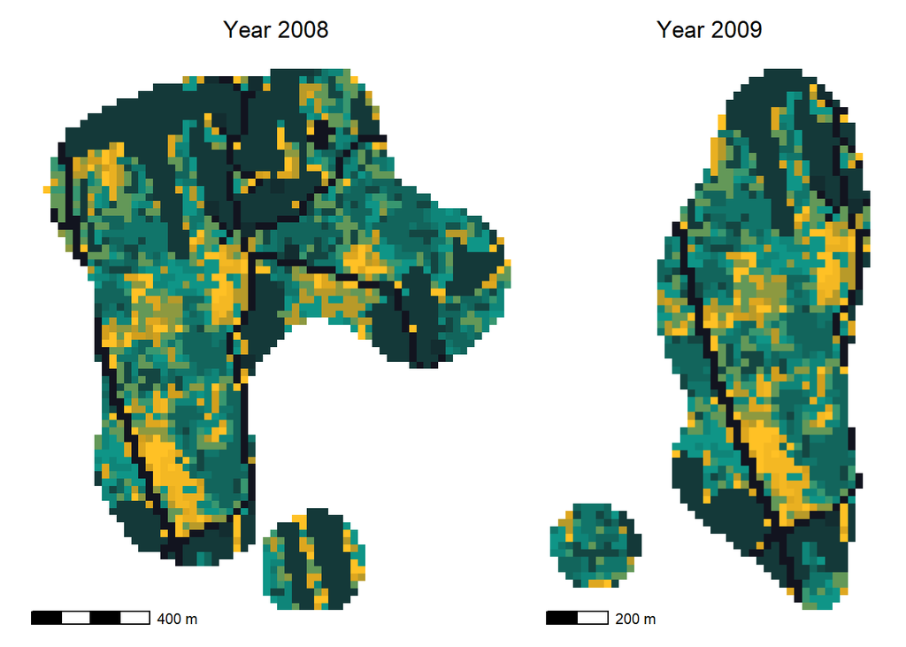

Now we extract the structural metrics using the `calculate_lsm()` - function for every element in our list. We calculated three metrics for every isoplets, namely: “patch density”, “edge density” and “percentage of landscape of class”.

```r
for (i in 1:nrow(iso)) {
  ras=raster("01_data/x7-1633348649-WTDhr19cl/WTDhr19cl.tif")
  ras = crop(mask(ras, iso$isopleth[[i]]), iso$isopleth[[i]])
  iso$lsm[[i]] <- calculate_lsm(ras, what=c("lsm_c_pd", "lsm_c_ed", "lsm_c_pland"))
}

iso <- iso %>% unnest_legacy(lsm)


head(iso)
```

```
## # A tibble: 6 x 9
##   hr_year season    prob_level layer level class    id metric value
##     <dbl> <chr>     <chr>      <int> <chr> <int> <int> <chr>  <dbl>
## 1    2008 hr_summer hr_80iso       1 class     1    NA ed      54.2
## 2    2008 hr_summer hr_80iso       1 class     2    NA ed      11.4
## 3    2008 hr_summer hr_80iso       1 class     3    NA ed      11.4
## 4    2008 hr_summer hr_80iso       1 class     4    NA ed      36.2
## 5    2008 hr_summer hr_80iso       1 class     5    NA ed      16.3
## 6    2008 hr_summer hr_80iso       1 class     6    NA ed      45.6
```

# 2 Compositional analysis

```r
both = read.csv("05_appendices/final_data.csv")

wtd50 <- filter(both, species=="whitetaileddeer" & prob_level=="prob50" & season=="hr_summer")
rd50 <- filter(both, species=="roedeer" & prob_level=="prob50" & season=="hr_summer")
```

```r
x=wtd50

  obs <- x %>% filter(case_==1)
  obs <- obs %>% dplyr::select(contains("pland"))
  obs[obs == 0] <- 0.001
  obs= mutate_all(obs, ~if_else(is.na(.), 0.001, .))
  obs$other_pland <- obs$other_pland+obs$water_pland
  obs$water_pland <- NULL

  avail= read.csv("01_data/studyarea_proportions.csv")
  avail$Freq <- NULL
  avail$X <- NULL
  avail$class <- paste(avail$class, "_pland", sep="")
  avail = avail %>% pivot_wider(values_from = Percent, names_from = class)
  avail[avail == 0] <- 0.001
  avail$other_pland <- avail$other_pland+avail$water_pland
  avail$water_pland <- NULL

  for(i in 1:nrow(obs)) avail[i,] = avail[1,]

  obs= obs[,order(colnames(obs))]
  avail=avail[,order(colnames(avail))]
```

Now we are ready to conduct the compositional analysis using the `compana()` - function.

```r
comp1 = compana(used=obs, avail=avail, test="randomisation", alpha=0.05, nrep=10000)
```

Thereafter, we extracted the six most selected for habitat classes from the compositional analysis as described in the main article and created the formula for the global model for the `predge()` - function.

```r
data = as.data.frame(comp1$rank) %>% rownames_to_column(c("habitat")) %>% rename(ranking= 2)

obj = tail(arrange(data, ranking), n=6)
  obj$habitat = substr(obj$habitat,1,nchar(obj$habitat)-6)
  obj$habitat1 <- paste(obj$habitat,"_pland", sep="")
  obj$habitat2 <- paste(obj$habitat,"_ed", sep="")
  obj$habitat3 <- paste(obj$habitat,"_pd", sep="")

obj
```

```
##                habitat ranking                  habitat1               habitat2
## 13  young_forest_mixed      12  young_forest_mixed_pland  young_forest_mixed_ed
## 14  young_forest_decid      13  young_forest_decid_pland  young_forest_decid_ed
## 15   spruce_plantation      14   spruce_plantation_pland   spruce_plantation_ed
## 16 young_forest_spruce      15 young_forest_spruce_pland young_forest_spruce_ed
## 17    mixed_plantation      16    mixed_plantation_pland    mixed_plantation_ed
## 18         agriculture      17         agriculture_pland         agriculture_ed
##                  habitat3
## 13  young_forest_mixed_pd
## 14  young_forest_decid_pd
## 15   spruce_plantation_pd
## 16 young_forest_spruce_pd
## 17    mixed_plantation_pd
## 18         agriculture_pd
```

```r
newformula =  obj %>% dplyr::select(habitat1, habitat2, habitat3) %>% pivot_longer(contains("habitat"))

vars <- paste(newformula$value, collapse = "+")
formula_all <- paste("case_ ~ (1|location)", vars, sep="+")
```

`obj` is now a dataframe containing the habitat classes and their respective structural metrics as they are called in the analysis. `formula_all` is the respective formula for the analysis, containing all habitat classes and their respective metrics.

All numeric variables in the `wtd50` data frame were centered and scaled first.

First, we compiled a model containing all variables and screened them for multicollinearity using the `vif()`-function in the `performance` - package. We then proceeded to remove them in a stepwise approach.

```r
  x = x %>%
    mutate(case_ = as.character(case_)) %>%
    mutate_if(is.numeric, scale) %>%
    mutate(case_ = as.numeric(as.logical(case_)))

  model <- glmer(formula(formula_all),
                 family = "binomial",
                 data = x)

  vif <- performance::check_collinearity(model)



  if (max(vif$VIF)<10) {
    message("")
  }  else { repeat {
    vif <- vif %>% filter(VIF<max(VIF))
    formula <- paste(vif$Term, collapse="+")
    formula_filter <- paste("case_ ~ (1|location)", formula, sep="+")
    model <- glmer(formula(formula_filter),
                   family = "binomial",
                   data = x,
                   glmerControl(optimizer="bobyqa",
                                optCtrl=list(maxfun=500000)))
    vif <- performance::check_collinearity(model)
    # exit if the condition is met
    if (max(vif$VIF) < 10) {
      model <<- model
      message("")
      break
    }
  }
  }
```

The last step removed all variables with potential multicollinearity issues.

Now we set up a parallel processing environment to speed up computational time and then calculates all possible models from our dataframe.

```r
require(parallel) || require(snow)
  clusterType <- if(length(find.package("snow", quiet = TRUE))) "SOCK" else "PSOCK"
  clust <- try(makeCluster(getOption("cl.cores", 7), type = clusterType))

  clusterExport(clust, "model")
  clusterExport(clust, "x")
  clusterEvalQ(clust, library("lme4"))


  model_all <- pdredge(model, cluster = clust)

  stopCluster(clust)
```

## 2.1 Model averaging

```r
summary(model.avg(get.models(model,subset = delta < 2)))
```

```
##
## Call:
## model.avg(object = get.models(model, subset = delta < 2))
##
## Component model call:
## glmer(formula = case_ ~ <11 unique rhs>, data = x, family = binomial(),
##      control = glmerControl(optimizer = "bobyqa", optCtrl = list(maxfun =
##      5e+05)))
##
## Component models:
##              df logLik   AICc delta weight
## 1+2+4+7       6 -98.30 208.72  0.00   0.19
## 2+3+4+7       6 -98.89 209.90  1.18   0.10
## 1+2+4+6+7     7 -97.90 209.96  1.24   0.10
## 1+2+4+7+11    7 -97.95 210.06  1.34   0.09
## 1+2+4+7+8     7 -98.03 210.21  1.50   0.09
## 1+2+4+7+10    7 -98.16 210.49  1.77   0.08
## 1+2+4+5+7     7 -98.21 210.57  1.85   0.07
## 1+2+4+6+7+8   8 -97.21 210.63  1.91   0.07
## 1+2+4+7+9     7 -98.24 210.63  1.91   0.07
## 1+2+4+6+7+11  8 -97.23 210.67  1.95   0.07
## 1+2+3+4+7     7 -98.27 210.69  1.97   0.07
##
## Term codes:
##            agriculture_ed            agriculture_pd         agriculture_pland
##                         1                         2                         3
##    mixed_plantation_pland   spruce_plantation_pland     young_forest_decid_pd
##                         4                         5                         6
##  young_forest_decid_pland     young_forest_mixed_pd  young_forest_mixed_pland
##                         7                         8                         9
##    young_forest_spruce_pd young_forest_spruce_pland
##                        10                        11
##
## Model-averaged coefficients:
## (full average)
##                            Estimate Std. Error Adjusted SE z value Pr(>|z|)
## (Intercept)               -4.413366   0.759108    0.760403   5.804  < 2e-16 ***
## agriculture_ed             0.557975   0.344410    0.344799   1.618   0.1056
## agriculture_pd             0.956535   0.216389    0.216724   4.414 1.02e-05 ***
## mixed_plantation_pland     0.477402   0.202693    0.203026   2.351   0.0187 *
```

[output cut: 10 more lines]

```
##                           Estimate Std. Error Adjusted SE z value Pr(>|z|)
## (Intercept)                -4.4134     0.7591      0.7604   5.804  < 2e-16 ***
## agriculture_ed              0.6217     0.3042      0.3047   2.041   0.0413 *
## agriculture_pd              0.9565     0.2164      0.2167   4.414 1.02e-05 ***
## mixed_plantation_pland      0.4774     0.2027      0.2030   2.351   0.0187 *
## young_forest_decid_pland    0.5727     0.2686      0.2690   2.129   0.0333 *
## agriculture_pland           0.3023     0.3467      0.3472   0.871   0.3838
## young_forest_decid_pd      -0.3813     0.3579      0.3585   1.063   0.2876
## young_forest_spruce_pland   0.2826     0.2965      0.2970   0.952   0.3413
## young_forest_mixed_pd       0.3614     0.3985      0.3991   0.905   0.3652
## young_forest_spruce_pd      0.1546     0.2976      0.2981   0.519   0.6041
## spruce_plantation_pland    -0.1271     0.2987      0.2992   0.425   0.6710
## young_forest_mixed_pland    0.1293     0.3623      0.3629   0.356   0.7216
## ---
## Signif. codes:  0 '***' 0.001 '**' 0.01 '*' 0.05 '.' 0.1 ' ' 1
```

# 3 Overlap analysis

The overlap analysis has been conducted as follows. We used the previous data from the compositional analysis, this time frome the 95% isopleths.

## 3.1 Prepare data for beta regression

First we defined a function to transform our response variable (the proportional overlap as recommended) for the regression.

```r
overlap_analysis = read.csv("C:/Users/grafluca/Desktop/habitat_selection_rd_wtd/05_appendices/overlap.csv")

head(overlap_analysis)
```

```
##   X.1 X  hr_level      value           id hr_year species sex      x_      y_
## 1   1 1 overlap50 0.04573618 cc_fi_08_001    2008 roedeer   M 3516497 6848388
## 2   2 2 overlap80 0.08772856 cc_fi_08_001    2008 roedeer   M 3516497 6848388
## 3   3 3 overlap95 0.17083864 cc_fi_08_001    2008 roedeer   M 3516497 6848388
## 4   4 4 overlap50 0.04350822 cc_fi_08_002    2008 roedeer   F 3517779 6847147
## 5   5 5 overlap80 0.21058475 cc_fi_08_002    2008 roedeer   F 3517779 6847147
## 6   6 6 overlap95 0.45804022 cc_fi_08_002    2008 roedeer   F 3517779 6847147
##      season prob_level level case_ Open1_ed  Open2_ed peatland_sparse_ed
## 1 hr_summer     prob50 class  TRUE 22.43872  3.645506           5.531113
## 2 hr_summer     prob80 class  TRUE 26.87861  3.809774           4.624277
## 3 hr_summer     prob95 class  TRUE 31.13882  7.145863           7.528404
## 4 hr_summer     prob50 class  TRUE 58.83408 25.112108          23.677130
## 5 hr_summer     prob80 class  TRUE 54.23729 11.402157          11.402157
## 6 hr_summer     prob95 class  TRUE 52.19929  7.087763           7.671461
##   pine_plantation_ed spruce_plantation_ed decid_plantation_ed
```

[output cut: 125 more lines]

```r
betareg_transform = function(y) {
  (y*(length(y)-1)+0.5)/length(y)
}

prop95 = filter(overlap_analysis, prob_level=="prob95")
prop95$value <- betareg_transform(prop95$value)
```

## 3.2 differences between species

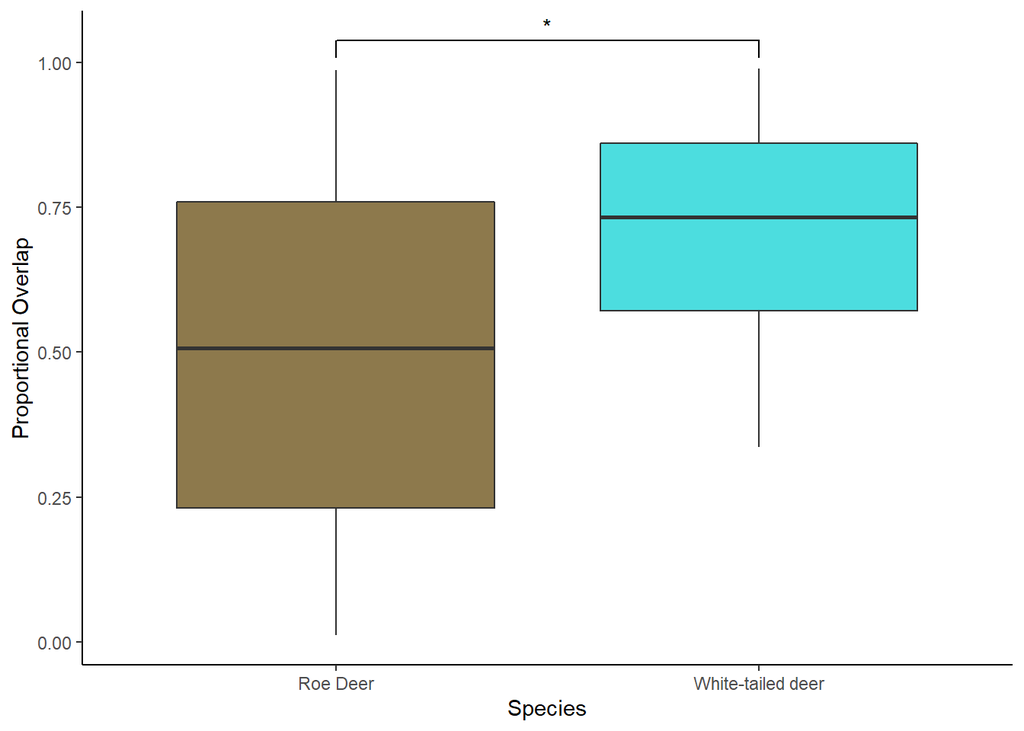

```r
b<-ggplot(prop95, aes(x=species, y=value,fill=species)) +
  geom_boxplot() +
  #facet_wrap() +
  geom_signif(map_signif_level=TRUE, comparisons = list(c("roedeer", "whitetaileddeer"))) +
  theme_classic() +
  scale_x_discrete(labels=c("Roe Deer", "White-tailed deer")) +
  xlab("Species") +
  ylab("Proportional Overlap") +
  scale_fill_witcher_d(option="uma", alpha=0.7) +
  theme(legend.position = "none");b
```

```r
wilcox.test(prop95$value~prop95$species)
```

```
##
##  Wilcoxon rank sum exact test
##
## data:  prop95$value by prop95$species
## W = 146, p-value = 0.02427
## alternative hypothesis: true location shift is not equal to 0
```

## 3.3 modeling and model averaging

In the next step, we formulated the models, using the `gam`() - function out of the mgcv - package, using a beta-regression as we were modelling fractions as our response variable.

```r
modelRD=  gam(value ~
               sex*( agriculture_pland +forest_area + scaled_y),
               data=filter(prop95, species=="roedeer"),family = betar(link = "logit"))

modeWTD=  gam(value ~
               sex*( + agriculture_pland +forest_area+scaled_y),
             data=filter(prop95, species!="roedeer"),family = betar(link = "logit"))

summary(modelRD)
```

```
##
## Family: Beta regression(3.906)
## Link function: logit
##
## Formula:
## value ~ sex * (agriculture_pland + forest_area + scaled_y)
##
## Parametric coefficients:
##                         Estimate Std. Error z value Pr(>|z|)
## (Intercept)             18.45627    7.08138   2.606  0.00915 **
## sexM                   -19.06773    7.82540  -2.437  0.01482 *
## agriculture_pland       -0.14627    0.06267  -2.334  0.01960 *
## forest_area             -0.23868    0.09573  -2.493  0.01266 *
## scaled_y                 0.09161    0.33731   0.272  0.78595
## sexM:agriculture_pland   0.17732    0.07685   2.307  0.02104 *
## sexM:forest_area         0.22658    0.10354   2.188  0.02865 *
## sexM:scaled_y           -0.40444    0.40018  -1.011  0.31219
## ---
## Signif. codes:  0 '***' 0.001 '**' 0.01 '*' 0.05 '.' 0.1 ' ' 1
##
##
## R-sq.(adj) =  0.441   Deviance explained =   71%
## -REML = 1.8516  Scale est. = 1         n = 18
```

```r
summary(modeWTD)
```

```
##
## Family: Beta regression(6.857)
## Link function: logit
##
## Formula:
## value ~ sex * (+agriculture_pland + forest_area + scaled_y)
##
## Parametric coefficients:
##                         Estimate Std. Error z value Pr(>|z|)
## (Intercept)            -2.218670   1.866954  -1.188   0.2347
## sexM                   -2.278804   6.076957  -0.375   0.7077
## agriculture_pland       0.042214   0.028067   1.504   0.1326
## forest_area             0.038565   0.020056   1.923   0.0545 .
## scaled_y               -0.575936   0.341872  -1.685   0.0921 .
## sexM:agriculture_pland -0.006776   0.065687  -0.103   0.9178
## sexM:forest_area        0.015943   0.076751   0.208   0.8354
## sexM:scaled_y           0.068189   0.912438   0.075   0.9404
## ---
## Signif. codes:  0 '***' 0.001 '**' 0.01 '*' 0.05 '.' 0.1 ' ' 1
##
##
## R-sq.(adj) =   0.41   Deviance explained = 62.7%
## -REML = -8.9338  Scale est. = 1         n = 27
```